# 12_metastatic_dataset

Andrea Polazzi

2026-03-26

# Setup

```r
library(tidyverse, quietly = T)
library(readxl)
source('../scripts/clean_columns.R')
knitr::opts_chunk$set(echo = FALSE, warning = FALSE, message = FALSE)
data <- read_xlsx('../data/raw/drivers.xlsx')
```

[output not shown]

```r
clean_data <- clean_drivers_data(data)

clean_data <- clean_data %>%
  distinct(patient_id, .keep_all = T) %>%
  select(tumor_tf_rate, `Intratel_reads/total_reads`, `tel_reads/total reads`, TCAGGG_singletons_norm_by_all_reads,
        TGAGGG_singletons_norm_by_all_reads, TTGGGG_singletons_norm_by_all_reads, TTCGGG_singletons_norm_by_all_reads,
        TTTGGG_singletons_norm_by_all_reads, ATAGGG_singletons_norm_by_all_reads, CTAGGG_singletons_norm_by_all_reads,
        GTAGGG_singletons_norm_by_all_reads, TAAGGG_singletons_norm_by_all_reads, tvr_all) %>%
  rename_with(~gsub('_singletons_norm_by_all_reads', '', .)) %>%
  rename(tel_insertion = `Intratel_reads/total_reads`, tel_content = `tel_reads/total reads`)

summary(clean_data)
```

```
##  tumor_tf_rate      tel_insertion        tel_content            TCAGGG
##  Min.   : 0.00000   Min.   :4.863e-06   Min.   :1.020e-05   Min.   :0.000e+00
##  1st Qu.: 0.00000   1st Qu.:1.153e-05   1st Qu.:3.084e-05   1st Qu.:2.090e-09
##  Median : 0.02125   Median :1.449e-05   Median :4.166e-05   Median :3.710e-09
##  Mean   : 0.07024   Mean   :1.768e-05   Mean   :5.149e-05   Mean   :7.366e-09
##  3rd Qu.: 0.05481   3rd Qu.:1.865e-05   3rd Qu.:5.585e-05   3rd Qu.:5.970e-09
##  Max.   :51.19476   Max.   :7.131e-04   Max.   :2.095e-03   Max.   :1.670e-06
##      TGAGGG              TTGGGG              TTCGGG
##  Min.   :2.730e-09   Min.   :0.000e+00   Min.   :0.000e+00
##  1st Qu.:2.900e-08   1st Qu.:7.692e-09   1st Qu.:4.080e-09
##  Median :4.370e-08   Median :1.230e-08   Median :6.690e-09
##  Mean   :5.467e-08   Mean   :1.471e-08   Mean   :1.134e-08
##  3rd Qu.:6.450e-08   3rd Qu.:1.750e-08   3rd Qu.:1.020e-08
##  Max.   :5.210e-06   Max.   :3.150e-07   Max.   :1.420e-06
##      TTTGGG              ATAGGG              CTAGGG
##  Min.   :9.620e-10   Min.   :0.000e+00   Min.   :0.000e+00
##  1st Qu.:8.582e-09   1st Qu.:9.680e-10   1st Qu.:2.190e-09
##  Median :1.210e-08   Median :1.910e-09   Median :4.160e-09
##  Mean   :1.625e-08   Mean   :2.559e-09   Mean   :5.485e-09
##  3rd Qu.:1.770e-08   3rd Qu.:3.190e-09   3rd Qu.:6.868e-09
##  Max.   :8.740e-07   Max.   :1.400e-07   Max.   :1.190e-07
##      GTAGGG              TAAGGG             tvr_all
##  Min.   :0.000e+00   Min.   :0.000e+00   Min.   :2.070e-08
##  1st Qu.:9.312e-09   1st Qu.:2.770e-09   1st Qu.:8.228e-08
##  Median :1.440e-08   Median :4.460e-09   Median :1.093e-07
##  Mean   :1.754e-08   Mean   :5.804e-09   Mean   :1.357e-07
##  3rd Qu.:2.050e-08   3rd Qu.:6.747e-09   3rd Qu.:1.443e-07
##  Max.   :9.790e-07   Max.   :1.220e-06   Max.   :8.392e-06
```

**Importantly** we don’t have info on TERT expression in this dataset. Moreover, TVR motifs are expressed in counts normalized by total reads.

# PCA biplots

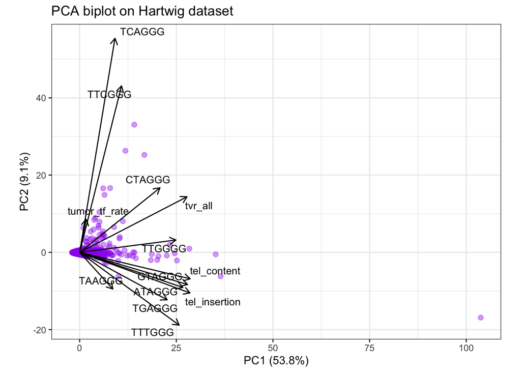

The PCA shows that the **main axis of variance is PC1**, strongly driven by `tel_content`, `tel_insertion`, and several TVR motifs (`GTAGGG`, `ATAGGG`, `TTGGGG`, …). This can be interpreted as a **telomere abundance/instability axis**.

PC2 explains less variance (9.1%), but is dominated by motifs such as `TCAGGG` and `TTCGGG`, and slightly opposed by `TTTGGG`, `TGAGGG` and `TAAGGG`. This can be interpreted as a **composition axis of TVR motifs**.

The **dense cluster** at the origin suggests that **most tumors have a similar telomere signal**, whereas a small subset has distinct telomere activity (outliers).

**TF rate shows little contribution to variance**: it either has low variability, or is overshadowed by other collinear features (possibly tel_content/tel_insertion). For this reason, the next step in the analysis could be to repeat the PCA excluding for strong contributors such as tel_insertion and tel_content, in order to isolate TVR structure and see if motifs cluster more cleanly.

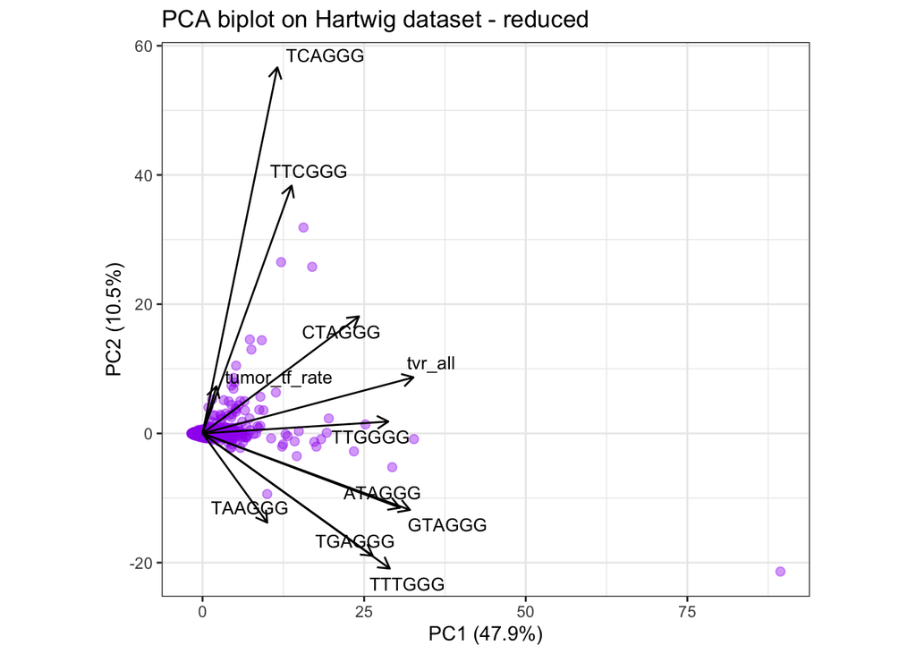

The **structure** and **features contribution** are **very similar to the last plot**, with TF rate showing very low variance explained and motifs explaining most of the vertical spread.

# Include also TERT mutation and cancer type info

```
##   patient_id        tumor_tf_rate     tel_insertion        tel_content
##  Length:3932        Min.   :0.00000   Min.   :4.863e-06   Min.   :1.020e-05
##  Class :character   1st Qu.:0.00000   1st Qu.:1.153e-05   1st Qu.:3.084e-05
##  Mode  :character   Median :0.02124   Median :1.449e-05   Median :4.166e-05
##                     Mean   :0.05689   Mean   :1.750e-05   Mean   :5.098e-05
##                     3rd Qu.:0.05469   3rd Qu.:1.865e-05   3rd Qu.:5.581e-05
##                     Max.   :5.57859   Max.   :4.386e-04   Max.   :6.699e-04
##      TCAGGG              TGAGGG              TTGGGG
##  Min.   :0.000e+00   Min.   :2.730e-09   Min.   :0.000e+00
##  1st Qu.:2.090e-09   1st Qu.:2.900e-08   1st Qu.:7.697e-09
##  Median :3.710e-09   Median :4.370e-08   Median :1.230e-08
##  Mean   :7.334e-09   Mean   :5.334e-08   Mean   :1.464e-08
##  3rd Qu.:5.970e-09   3rd Qu.:6.442e-08   3rd Qu.:1.750e-08
##  Max.   :1.670e-06   Max.   :2.290e-06   Max.   :2.640e-07
##      TTCGGG              TTTGGG              ATAGGG
##  Min.   :0.000e+00   Min.   :9.620e-10   Min.   :0.000e+00
##  1st Qu.:4.077e-09   1st Qu.:8.580e-09   1st Qu.:9.678e-10
##  Median :6.690e-09   Median :1.210e-08   Median :1.910e-09
##  Mean   :1.122e-08   Mean   :1.603e-08   Mean   :2.523e-09
##  3rd Qu.:1.020e-08   3rd Qu.:1.770e-08   3rd Qu.:3.190e-09
##  Max.   :1.420e-06   Max.   :5.310e-07   Max.   :9.510e-08
##      CTAGGG              GTAGGG              TAAGGG
##  Min.   :0.000e+00   Min.   :0.000e+00   Min.   :0.000e+00
##  1st Qu.:2.190e-09   1st Qu.:9.318e-09   1st Qu.:2.770e-09
##  Median :4.160e-09   Median :1.440e-08   Median :4.460e-09
##  Mean   :5.478e-09   Mean   :1.729e-08   Mean   :5.752e-09
##  3rd Qu.:6.863e-09   3rd Qu.:2.050e-08   3rd Qu.:6.742e-09
##  Max.   :1.190e-07   Max.   :3.520e-07   Max.   :1.220e-06
##     tvr_all           mixed_def             gene            TERT_mut
##  Min.   :2.070e-08   Length:3932        Length:3932        FALSE:3408
##  1st Qu.:8.226e-08   Class :character   Class :character   TRUE : 524
##  Median :1.093e-07   Mode  :character   Mode  :character
##  Mean   :1.336e-07
##  3rd Qu.:1.442e-07
##  Max.   :2.581e-06
```

## Removing TVR motifs

TVR motifs may act as confounders, masking the shared structure that could be explained by TF rate, tel. insertion and tel. content. Removing them could help us see if they are “masking” the telomere signal.

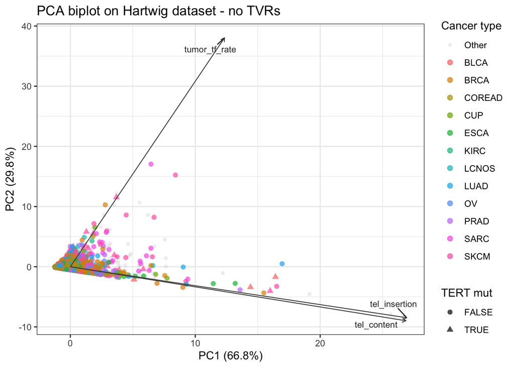

`tel_content` and `tel_insertion` confirm themselves as **strongly correlated features**, but it is **not the case for** `tumor_tf_rate` as well. It is an **independent “fusion activity” axis**, where orthogonality is not influenced by TVR motifs or scaling issues, but is intrinsic.

```
## [1] 0.1010425
```

```
## [1] 0.2219384
```

Spearman correlations between tumor fusion rate and telomere content (ρ ≈ 0.10) and telomere insertion rate (ρ ≈ 0.22) are low, indicating **weak monotonic association**.

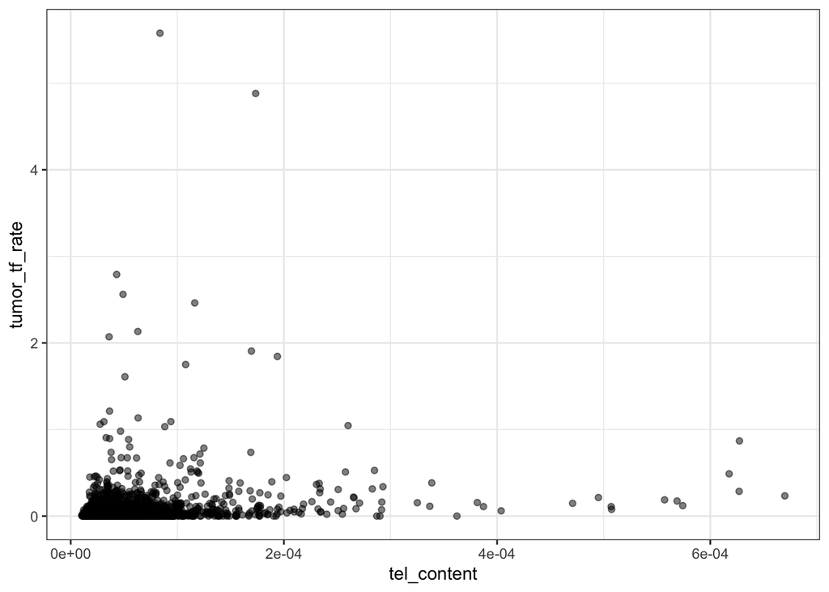

[figure not shown]

## Remove outliers and colour by cancer type + TERT mutation

We now try to discriminate, using all features, among cancer types and patients with registered TERT mutations.

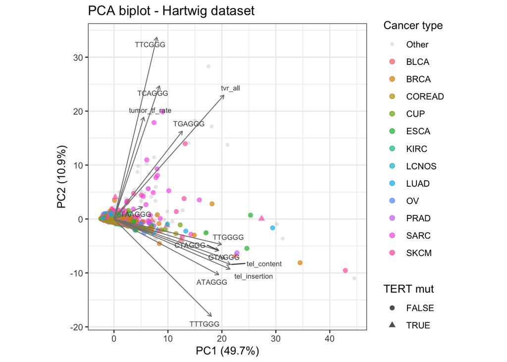

# Trying with UMAP

PCA finds the main linear directions of variation and is interpretable through feature loadings, whereas **UMAP preserves local neighborhood structure** and is better suited to **reveal non-linear clustering patterns**.

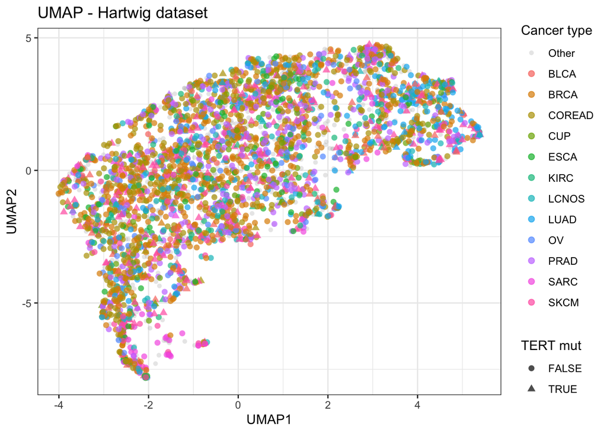

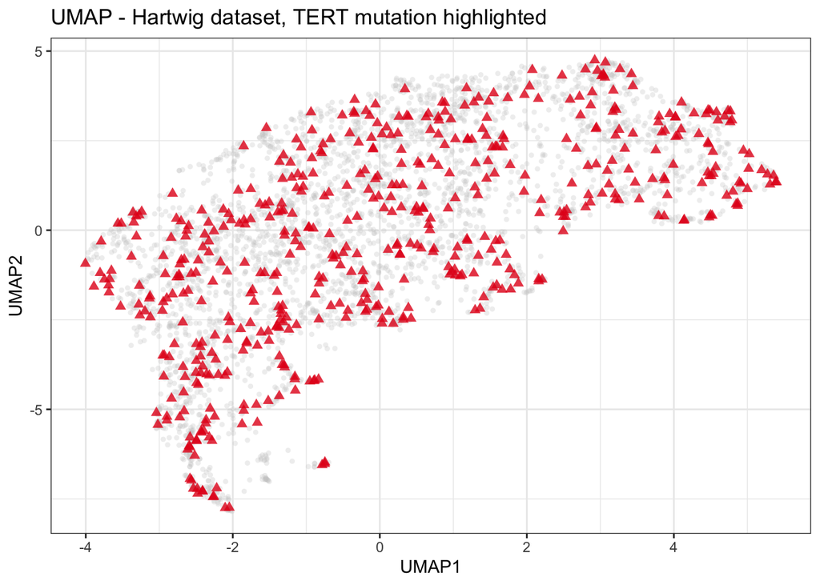